# Лабораторная работа №14

Партиции, файловые системы, монтирование

Ришард Когенгар

Российский университет дружбы народов, Москва, Россия

22 января 2026

# Цель работы

## Основная цель

- Получить навыки создания разделов на диске (MBR и GPT)
- Получить навыки создания файловых систем (XFS, EXT4)
- Освоить ручное и автоматическое монтирование
- Настроить и проверить пространство подкачки (swap)

# Ход выполнения работы

## Добавление виртуальных дисков в VirtualBox

- В VirtualBox добавлены два дополнительных диска (**VDI**, динамические)
- Подключение: контроллер **SATA**
- Названия: **rishardkogengar_1.vdi**, **rishardkogengar_2.vdi**
- Назначение: отработка разметки и файловых систем

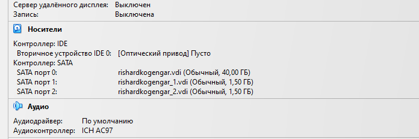

Добавленные виртуальные носители

## Проверка подключённых дисков в системе

- Выполнен просмотр устройств хранения
- Основной диск: **/dev/sda** (40 ГБ)
- Дополнительные диски: **/dev/sdb**, **/dev/sdc**

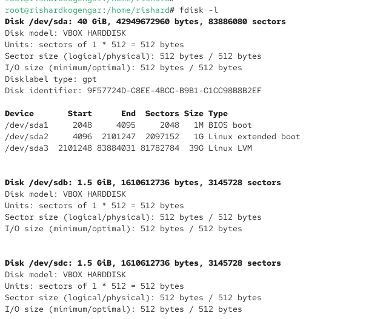

Список доступных дисков

## Разметка MBR на /dev/sdb

- Запуск утилиты разметки для MBR
- Создание таблицы разделов **DOS (MBR)**
- Подготовка диска к созданию разделов

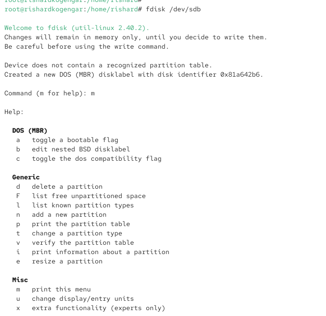

Запуск fdisk и создание MBR

## Создание первичного раздела /dev/sdb1

- Создан **primary** раздел №1
- Размер: **300 MiB** (параметр +300M)
- Тип: **83 (Linux)**
- Выполнена запись изменений на диск

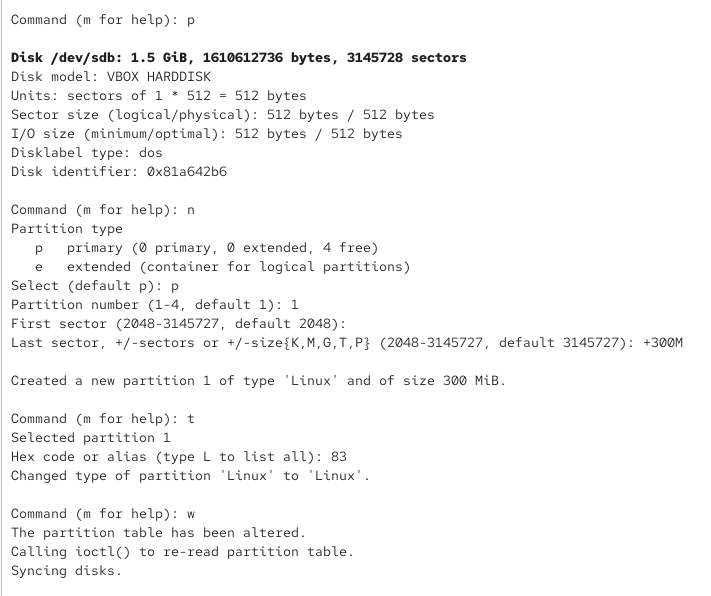

Создание первичного раздела

## Обновление таблицы разделов ядра

- Сравнение сведений о разделах (диск vs ядро)
- Обновление информации в ядре средствами **partprobe**
- Подтверждение появления нового раздела

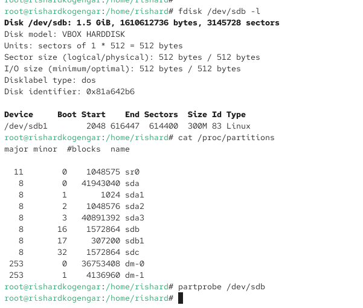

Обновление таблицы разделов ядра

## Создание расширенного и логического разделов

- Создан расширенный раздел **/dev/sdb4** (extended) на оставшееся пространство
- Создан логический раздел **/dev/sdb5** (300 MiB, тип 83)
- Выполнено обновление таблицы разделов

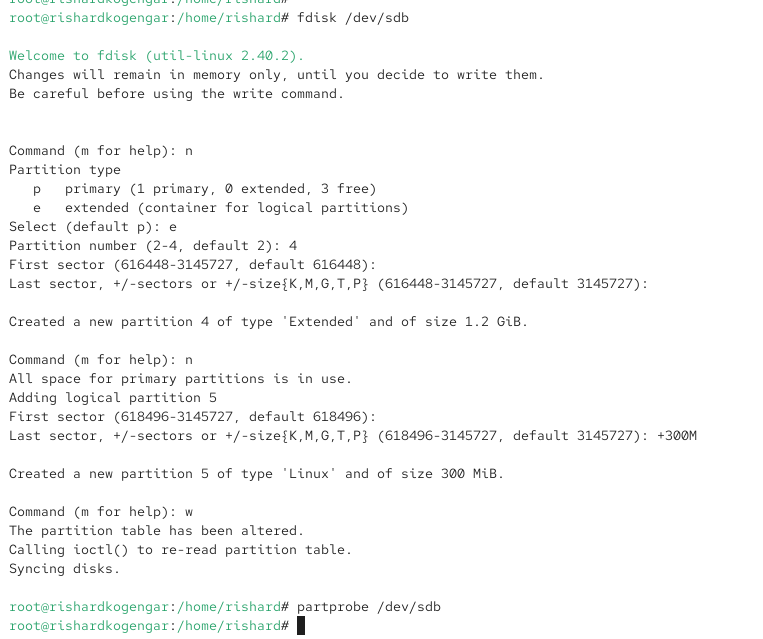

Создание расширенного раздела

## Итоговая проверка разметки /dev/sdb

- Подтверждено наличие:
  - **/dev/sdb1** (primary)
  - **/dev/sdb4** (extended)
  - **/dev/sdb5** (logical)
- Разметка MBR выполнена корректно

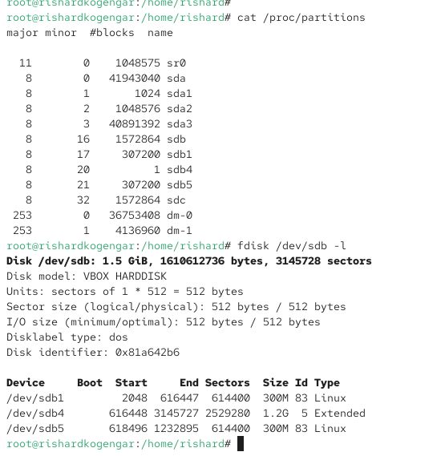

Итоговая таблица разделов

## Создание swap-раздела на /dev/sdb

- Создан логический раздел **/dev/sdb6** размером **300 MiB**
- Изменён тип раздела на **82 (Linux swap)**
- Изменения записаны на диск

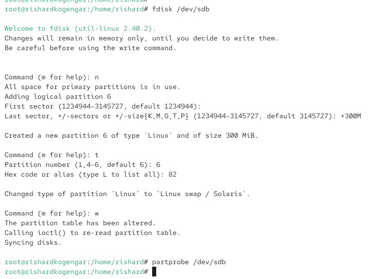

Создание логического раздела под swap

## Обновление и проверка swap-раздела

- Выполнена синхронизация таблицы разделов
- Подтверждено наличие **/dev/sdb6** типа swap

[figure not shown]

## Инициализация и включение swap

- Раздел подкачки инициализирован
- Swap подключён в системе
- Проверена доступная память и объём swap

[figure not shown]

## Разметка GPT на /dev/sdc

- Для диска **/dev/sdc** использована утилита разметки GPT
- При отсутствии разметки создана таблица **GPT**
- Подготовка диска к созданию разделов

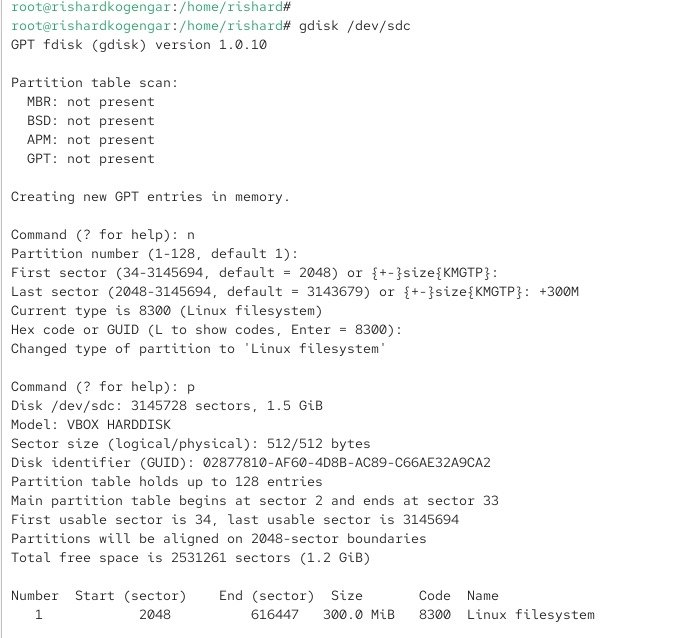

Просмотр таблицы разделов GPT

## Создание GPT-раздела /dev/sdc1

- Создан раздел №1 размером **300 MiB**
- Тип: **8300 (Linux filesystem)**
- Изменения записаны на диск и применены

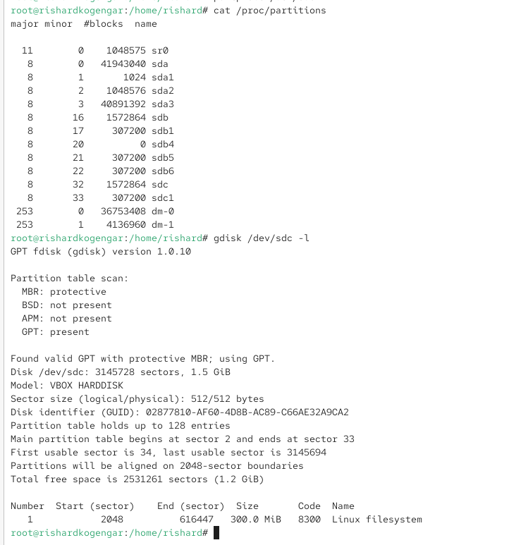

Итоговая проверка GPT-разделов

## Форматирование XFS на /dev/sdb1

- Создана файловая система **XFS** на **/dev/sdb1**
- Установлена метка тома: **xfsdisk**

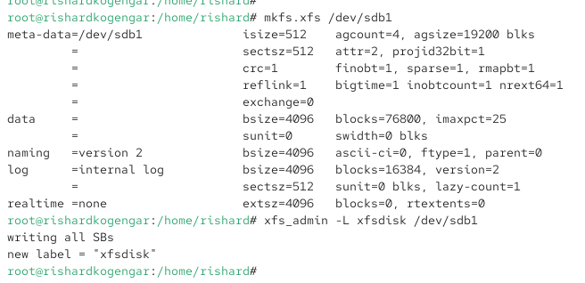

Форматирование раздела XFS

## Форматирование EXT4 на /dev/sdb5

- Создана файловая система **EXT4** на **/dev/sdb5**
- Установлена метка: **ext4disk**
- Включены параметры монтирования: **acl**, **user_xattr**

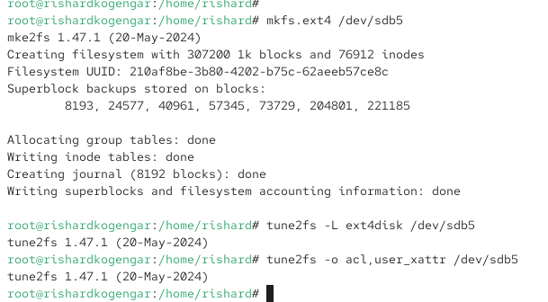

Форматирование раздела EXT4

## Ручное монтирование EXT4

- Создана точка монтирования **/mnt/tmp**
- Раздел **/dev/sdb5** смонтирован и проверен
- Выполнено корректное отмонтирование

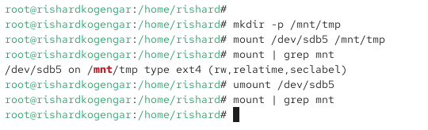

Проверка ручного монтирования

## Автомонтирование через /etc/fstab (XFS)

- Создан каталог **/mnt/data**
- Получен UUID для **/dev/sdb1**
- Добавлена запись в **/etc/fstab** для монтирования XFS

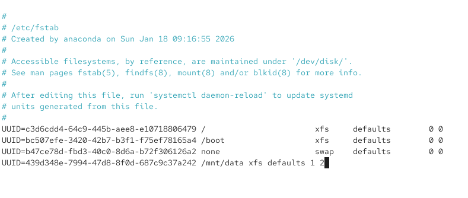

Редактирование файла fstab

## Проверка автомонтирования

- Выполнена проверка конфигурации монтирования
- Подтверждено, что **/dev/sdb1** смонтирован в **/mnt/data**
- Проверен объём и доступное место

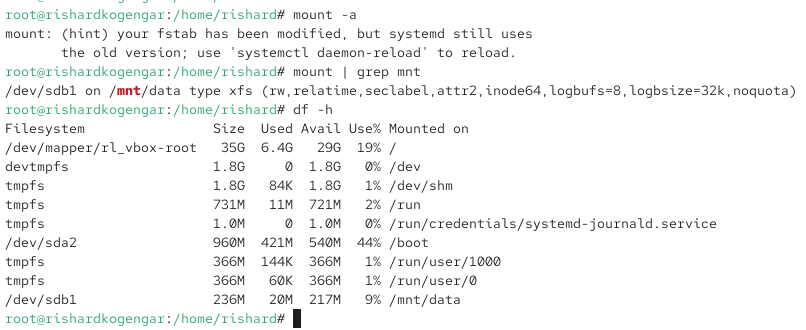

Итоговая проверка монтирования

# Самостоятельная работа

## Разделы на GPT-диске /dev/sdc

- Созданы дополнительные разделы на **/dev/sdc**
- Назначение:
  - **ext4**-раздел для монтирования
  - **swap**-раздел для подкачки
- Изменения сохранены и применены

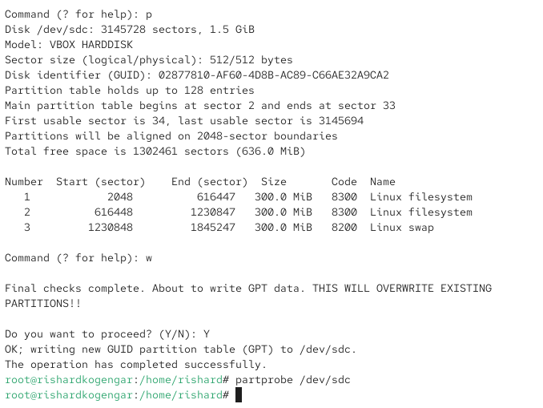

Разметка GPT-диска с несколькими разделами

## Форматирование и настройка разделов

- Для **/dev/sdc2** создана файловая система **EXT4**
- Установлена метка: **ext4disk2**
- Для **/dev/sdc3** выполнена инициализация swap

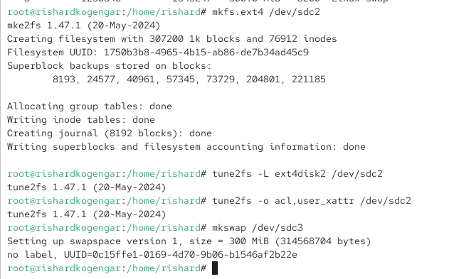

Форматирование EXT4 и создание swap на GPT-диске

## Автомонтирование ext4 и автоподключение swap

- Получены UUID новых разделов
- В **/etc/fstab** добавлены записи:
  - монтирование EXT4 в **/mnt/data-ext**
  - подключение swap по UUID

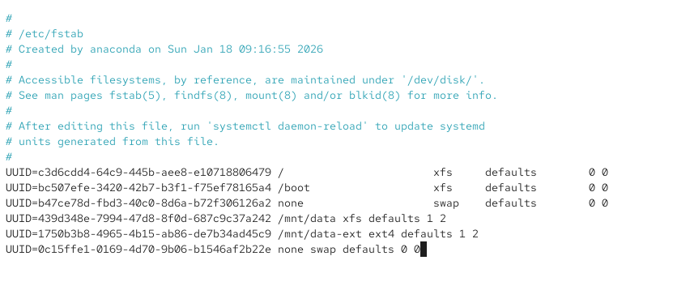

Записи для ext4 и swap в fstab

## Контроль после настройки

- Проверено:
  - наличие монтирования **/mnt/data-ext**
  - активное пространство swap
  - корректное отображение в выводе системных утилит

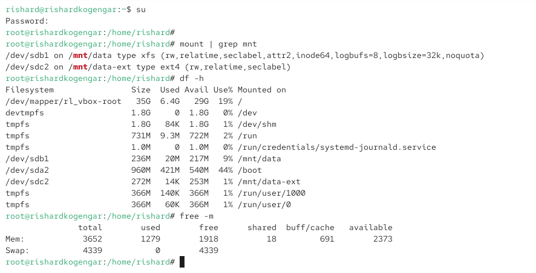

Итоговая проверка монтирования и swap

# Итоги работы

## Вывод

- Выполнена разметка дисков с использованием **MBR (fdisk)** и **GPT (gdisk)**
- Созданы файловые системы **XFS** и **EXT4**, настроены метки и параметры
- Настроены ручное монтирование и автомонтирование через **/etc/fstab**
- Создано и подключено пространство подкачки, выполнена проверка работоспособности
- Система корректно применяет настройки монтирования и swap после настройки